# R Notebook

Alyssa Knapp

12/10/20

# Final Project: UFO Sightings & U.S. Air Quality

## Research Question

Where are UFO sightings in the United States associated with pollutant levels of carbon monoxide (CO) and nitrogen dioxide (NO2) and how do these levels change over time?

## Purpose

This topic is important to investigate because there is currently very little knowledge of how climate information relates to UFO sightings. Air quality, in particular, is interesting to explore because air pollutants can impair visibility, which may affect the ability of UFOs to be seen in the sky. This “relationship” is expected to become more polarized over time, as air quality worsens.

## Data Access

```r
library(mosaic)
library(ggplot2)
library(tidyverse)
library(dplyr)
library(knitr)
library(lubridate)
library(readxl)
library(DataComputing)
```

```r
rm(list=ls())
```

```r
#Data Set 1
UFO <- read_excel("UFOs_coord.xlsx")
```

```r
#Data Set 2
AirQ <- read.csv("UFOPOLLUTANTS.csv", header = TRUE)
```

## Inspecting Data Sets

```r
#Data Set 1
kable(head(UFO))
```

| Date.Time | Country | City | State | Shape | Summary | lat | lng |
| --- | --- | --- | --- | --- | --- | --- | --- |
| 12/21/16 19:15 | USA | Waynesboro | VA | Sphere | Bright round object hovering in sky. | 38.06523 | -78.90589 |
| 12/21/16 00:00 | USA | Louisville | KY | Unknown | Multiple craft ascending from north of Shelbyville road, very bright and |  |  |
| very quiet in comparison to passenger planes seen in the sky a | 38.25424 | -85.75941 |  |  |  |  |  |
| 12/20/16 22:30 | USA | Santa Rosa | CA | Sphere | Bright orange planet-like object sighted near Cassiopia | 38.44047 | -122.71443 |
| 12/20/16 19:00 | USA | Fresno | CA | Circle | Twelve orange globes in formation over Fresno | 36.72953 | -119.70886 |
| 12/19/16 21:53 | USA | Reymert | AZ | Circle | While camping in the Cottonwood canyon Rd., along the gas line rd., I awoke |  |  |
| to my dog growling and staring north. I looked to see what | 33.22978 | -111.20929 |  |  |  |  |  |
| 12/19/16 21:50 | USA | Redding | CA | Light | Stargazing I saw a star just appear then moves slowly then gradually fade |  |  |
| out | 40.58636 | -122.39168 |  |  |  |  |  |

```r
glimpse(UFO)
```

```
Rows: 5,177
Columns: 8
$ Date.Time <chr> "12/21/16 19:15", "12/21/16 00:00", "12/20/16 22:30", "12/20/16 19:00", "12/19/16 21:53", "12/19/16 21:50", "12/19/16 20:02", "12/19/16 19:02", "1...
$ Country   <chr> "USA", "USA", "USA", "USA", "USA", "USA", "USA", "USA", "USA", "USA", "USA", "USA", "USA", "USA", "CANADA", "USA", "USA", "USA", "USA", "USA", "US...
$ City      <chr> "Waynesboro", "Louisville", "Santa Rosa", "Fresno", "Reymert", "Redding", "Gilbert", "Phoenix", "Huber Heights", "Conway", "Anchorage", "Town and ...
$ State     <chr> "VA", "KY", "CA", "CA", "AZ", "CA", "AZ", "AZ", "OH", "AR", "AK", "MO", "UT", "TX", "AB", "AR", "HI", "UT", "OR", "KS", "OH", "CA", "HI", "CA", "H...
$ Shape     <chr> "Sphere", "Unknown", "Sphere", "Circle", "Circle", "Light", "Light", "Circle", "Cylinder", "Chevron", "Circle", "Light", "Triangle", "Triangle", "...
$ Summary   <chr> "Bright round object hovering in sky.", "Multiple craft ascending from north of Shelbyville road, very bright and \r\nvery quiet in comparison to ...
$ lat       <dbl> 38.06523, 38.25424, 38.44047, 36.72953, 33.22978, 40.58636, 33.29421, 33.44859, 39.85902, 35.08870, 61.21631, 38.61228, 40.76701, 32.94818, 52.968...
$ lng       <dbl> -78.90589, -85.75941, -122.71443, -119.70886, -111.20929, -122.39168, -111.73795, -112.07735, -84.11136, -92.44210, -149.89485, -90.46345, -111.89...
```

```r
str(UFO)
```

```
tibble [5,177 x 8] (S3: tbl_df/tbl/data.frame)
 $ Date.Time: chr [1:5177] "12/21/16 19:15" "12/21/16 00:00" "12/20/16 22:30" "12/20/16 19:00" ...
 $ Country  : chr [1:5177] "USA" "USA" "USA" "USA" ...
 $ City     : chr [1:5177] "Waynesboro" "Louisville" "Santa Rosa" "Fresno" ...
 $ State    : chr [1:5177] "VA" "KY" "CA" "CA" ...
 $ Shape    : chr [1:5177] "Sphere" "Unknown" "Sphere" "Circle" ...
 $ Summary  : chr [1:5177] "Bright round object hovering in sky." "Multiple craft ascending from north of Shelbyville road, very bright and \r\nvery quiet in comparison to passen"| __truncated__ "Bright orange planet-like object sighted near Cassiopia" "Twelve orange globes in formation over Fresno"…
 $ lat      : num [1:5177] 38.1 38.3 38.4 36.7 33.2 ...
 $ lng      : num [1:5177] -78.9 -85.8 -122.7 -119.7 -111.2 ...
```

```r
#Data Set 2
kable(head(AirQ))
```

| state | day | month | year | hour | NO2.Mean | NO2.Max.Value | NO2.Max.Hour | NO2.AQI | CO.Mean | CO.Max.Value | CO.Max.Hour | CO.AQI | ET |
| --- | --- | --- | --- | --- | --- | --- | --- | --- | --- | --- | --- | --- | --- |
| az | 7 | 7 | 2000 | 21 | 7.375000 | 15 | 6 | 14 | 0.195833 | 0.3 | 0 | 3 | 1 |
| az | 7 | 7 | 2000 | 21 | 7.375000 | 15 | 6 | 14 | 0.195833 | 0.3 | 0 | 3 | 1 |
| az | 6 | 9 | 2001 | 21 | 7.708333 | 19 | 6 | 18 | 0.175000 | 0.7 | 6 | NA | 1 |
| az | 5 | 6 | 2005 | 21 | 7.916667 | 17 | 6 | 16 | 0.416667 | 0.6 | 6 | NA | 1 |
| az | 5 | 10 | 2007 | 2 | 8.625000 | 20 | 6 | 19 | 0.212500 | 0.3 | 5 | NA | 1 |
| az | 5 | 10 | 2007 | 21 | 8.625000 | 20 | 6 | 19 | 0.212500 | 0.3 | 5 | NA | 1 |

```r
glimpse(AirQ)
```

```
Rows: 63,173
Columns: 14
$ state         <chr> "az", "az", "az", "az", "az", "az", "az", "az", "az", "az", "az", "az", "az", "az", "az", "az", "az", "az", "az", "az", "az", "az", "az", "az"...
$ day           <int> 7, 7, 6, 5, 5, 5, 6, 12, 7, 9, 6, 12, 10, 8, 8, 2, 2, 10, 8, 8, 9, 5, 5, 8, 10, 3, 8, 4, 5, 9, 2, 11, 5, 3, 2, 4, 9, 7, 6, 4, 11, 8, 1, 9, 3, ...
$ month         <int> 7, 7, 9, 6, 10, 10, 8, 9, 7, 10, 10, 3, 7, 6, 6, 4, 5, 4, 4, 4, 8, 4, 3, 9, 12, 9, 12, 4, 11, 10, 2, 10, 1, 3, 3, 4, 2, 2, 1, 7, 1, 1, 8, 4, 7...
$ year          <int> 2000, 2000, 2001, 2005, 2007, 2007, 2002, 2006, 2006, 2005, 2007, 2006, 2006, 2006, 2006, 2005, 2003, 2005, 2000, 2000, 2001, 2008, 2000, 2004...
$ hour          <int> 21, 21, 21, 21, 2, 21, 22, 5, 0, 20, 1, 19, 1, 17, 20, 20, 19, 18, 20, 20, 22, 8, 22, 22, 21, 15, 21, 21, 20, 20, 23, 17, 7, 21, 19, 20, 21, 2...
$ NO2.Mean      <dbl> 7.375000, 7.375000, 7.708333, 7.916667, 8.625000, 8.625000, 9.458333, 10.854167, 10.875000, 11.083333, 11.333333, 11.791667, 12.587500, 12.750...
$ NO2.Max.Value <dbl> 15.0, 15.0, 19.0, 17.0, 20.0, 20.0, 19.0, 27.3, 19.0, 26.0, 36.0, 44.0, 35.4, 22.0, 22.0, 45.0, 40.0, 41.8, 38.0, 38.0, 27.0, 49.0, 33.0, 45.0...
$ NO2.Max.Hour  <int> 6, 6, 6, 6, 6, 6, 21, 6, 0, 5, 22, 21, 21, 23, 23, 21, 0, 22, 0, 0, 6, 0, 17, 20, 18, 23, 17, 19, 23, 0, 19, 19, 22, 21, 20, 20, 18, 19, 18, 8...
$ NO2.AQI       <int> 14, 14, 18, 16, 19, 19, 18, 25, 18, 25, 34, 42, 33, 21, 21, 42, 38, 39, 36, 36, 25, 46, 31, 42, 32, 42, 34, 47, 35, 45, 39, 43, 35, 54, 49, 50...
$ CO.Mean       <dbl> 0.195833, 0.195833, 0.175000, 0.416667, 0.212500, 0.212500, 0.290909, 0.282609, 0.304167, 0.145833, 0.358333, 0.241667, 0.412500, 0.225000, 0....
$ CO.Max.Value  <dbl> 0.3, 0.3, 0.7, 0.6, 0.3, 0.3, 0.3, 0.8, 0.4, 0.3, 0.9, 0.6, 0.9, 0.3, 0.3, 0.5, 0.6, 0.7, 0.6, 0.6, 0.4, 0.8, 0.6, 1.7, 2.2, 0.4, 2.3, 0.9, 0....
$ CO.Max.Hour   <int> 0, 0, 6, 6, 5, 5, 1, 7, 0, 6, 22, 23, 22, 5, 5, 22, 0, 23, 1, 1, 7, 0, 19, 6, 20, 22, 7, 22, 23, 0, 23, 23, 23, 22, 23, 4, 23, 1, 23, 11, 22, ...
$ CO.AQI        <int> 3, 3, NA, NA, NA, NA, 3, NA, NA, NA, NA, 7, NA, NA, NA, 6, 7, 8, NA, NA, 5, NA, 7, NA, NA, 5, NA, 10, 5, NA, 15, 16, 13, NA, NA, 17, NA, 22, 3...
$ ET            <int> 1, 1, 1, 1, 1, 1, 1, 1, 1, 1, 1, 1, 1, 1, 1, 1, 1, 1, 1, 1, 1, 1, 1, 1, 1, 1, 1, 1, 1, 1, 1, 1, 1, 1, 1, 1, 1, 1, 1, 1, 1, 1, 1, 1, 1, 1, 1, 1...
```

```r
str(AirQ)
```

```
'data.frame':   63173 obs. of  14 variables:
 $ state        : chr  "az" "az" "az" "az" ...
 $ day          : int  7 7 6 5 5 5 6 12 7 9 ...
 $ month        : int  7 7 9 6 10 10 8 9 7 10 ...
 $ year         : int  2000 2000 2001 2005 2007 2007 2002 2006 2006 2005 ...
 $ hour         : int  21 21 21 21 2 21 22 5 0 20 ...
 $ NO2.Mean     : num  7.38 7.38 7.71 7.92 8.62 ...
 $ NO2.Max.Value: num  15 15 19 17 20 20 19 27.3 19 26 ...
 $ NO2.Max.Hour : int  6 6 6 6 6 6 21 6 0 5 ...
 $ NO2.AQI      : int  14 14 18 16 19 19 18 25 18 25 ...
 $ CO.Mean      : num  0.196 0.196 0.175 0.417 0.212 ...
 $ CO.Max.Value : num  0.3 0.3 0.7 0.6 0.3 0.3 0.3 0.8 0.4 0.3 ...
 $ CO.Max.Hour  : int  0 0 6 6 5 5 1 7 0 6 ...
 $ CO.AQI       : int  3 3 NA NA NA NA 3 NA NA NA ...
 $ ET           : int  1 1 1 1 1 1 1 1 1 1 ...
```

## Variables To Be Used (originally included in data sets)

Data Set 1 * country: will limit to only include USA * state: records data from certain states

Data Set 2 * state: records data from certain states * month: all 12 months * year: contains data from 2000 to 2008

- NO2/CO Mean: mean concentration within a given day
- NO2/CO AQI: Air quality index within a given day
- NO2/CO 1st Max Value: maximum value obtained within a given day
- NO2/CO 1st Max Hour: the hour when the maximum concentration was obtained
- ET: equal to 1 if a UFO was sighted, 0 otherwise (binary)

## Data Cleaning & Wrangling for Data Set 1

```r
#Limiting to USA only
UFO_US <-
  UFO %>%
  filter(Country == "USA")

UFO_US$State <- unlist(lapply(UFO_US$State, tolower))
str(UFO_US)
```

```
tibble [5,027 x 8] (S3: tbl_df/tbl/data.frame)
 $ Date.Time: chr [1:5027] "12/21/16 19:15" "12/21/16 00:00" "12/20/16 22:30" "12/20/16 19:00" ...
 $ Country  : chr [1:5027] "USA" "USA" "USA" "USA" ...
 $ City     : chr [1:5027] "Waynesboro" "Louisville" "Santa Rosa" "Fresno" ...
 $ State    : chr [1:5027] "va" "ky" "ca" "ca" ...
 $ Shape    : chr [1:5027] "Sphere" "Unknown" "Sphere" "Circle" ...
 $ Summary  : chr [1:5027] "Bright round object hovering in sky." "Multiple craft ascending from north of Shelbyville road, very bright and \r\nvery quiet in comparison to passen"| __truncated__ "Bright orange planet-like object sighted near Cassiopia" "Twelve orange globes in formation over Fresno"…
 $ lat      : num [1:5027] 38.1 38.3 38.4 36.7 33.2 ...
 $ lng      : num [1:5027] -78.9 -85.8 -122.7 -119.7 -111.2 ...
```

```r
#Creating Regions
UFO_US <-
  UFO_US %>%
  mutate(Region = ifelse(State %in% c("me","nh","vt","ri","ct","ny","pa","nj"), "Northeast",
  ifelse(State %in% c("wi","mi","il","oh","nd","sd","ne","ks","mn","ia","mo"),"Midwest", ifelse(State %in% c("de","md","va","wv","nc","sc","ga","fl","ky","ms","al","ok","tx","ar","la"), "South", "West"))))

Region_count <-
  UFO_US %>%
  group_by(Region) %>%
  summarise(total = count(State))

Region_count
```

| Region | total |
| --- | --- |
| Midwest | 40 |
| Northeast | 65 |
| South | 46 |
| West | 37 |

## Data Wrangling for Data Set 2

```r
#Converting variable types
Air_Q <-
  AirQ %>%
  mutate(time = make_datetime(year, month, day, hour),
  day = factor(day(time)),
  month = factor(month(time)),
  year = factor(year(time)),
  weekday = factor(wday(time)),
  hour = factor(hour(time)),
  date = as.Date(time))

names(Air_Q)[names(Air_Q) == "time"] <- "date_time"

#"date" variable is not needed since "date_time" contains the date & time
Air_Q$date <- NULL

kable(head(Air_Q))
```

| state | day | month | year | hour | NO2.Mean | NO2.Max.Value | NO2.Max.Hour | NO2.AQI | CO.Mean | CO.Max.Value | CO.Max.Hour | CO.AQI | ET | date_time | weekday |
| --- | --- | --- | --- | --- | --- | --- | --- | --- | --- | --- | --- | --- | --- | --- | --- |
| az | 7 | 7 | 2000 | 21 | 7.375000 | 15 | 6 | 14 | 0.195833 | 0.3 | 0 | 3 | 1 | 2000-07-07 21:00:00 | 6 |
| az | 7 | 7 | 2000 | 21 | 7.375000 | 15 | 6 | 14 | 0.195833 | 0.3 | 0 | 3 | 1 | 2000-07-07 21:00:00 | 6 |
| az | 6 | 9 | 2001 | 21 | 7.708333 | 19 | 6 | 18 | 0.175000 | 0.7 | 6 | NA | 1 | 2001-09-06 21:00:00 | 5 |
| az | 5 | 6 | 2005 | 21 | 7.916667 | 17 | 6 | 16 | 0.416667 | 0.6 | 6 | NA | 1 | 2005-06-05 21:00:00 | 1 |
| az | 5 | 10 | 2007 | 2 | 8.625000 | 20 | 6 | 19 | 0.212500 | 0.3 | 5 | NA | 1 | 2007-10-05 02:00:00 | 6 |
| az | 5 | 10 | 2007 | 21 | 8.625000 | 20 | 6 | 19 | 0.212500 | 0.3 | 5 | NA | 1 | 2007-10-05 21:00:00 | 6 |

```r
#Filter to only include UFO sightings
Air_Q <-
  Air_Q %>%
  filter(ET == 1)

#Add labels
Air_Q$month <- factor(Air_Q$month, labels = c("Jan", "Feb", "Mar", "Apr", "May", "Jun", "Jul", "Aug", "Sep","Oct", "Nov", "Dec"))
Air_Q$weekday <- factor(Air_Q$weekday,labels = c("Mon", "Tue", "Wed", "Thu", "Fri", "Sat", "Sun"))
str(Air_Q)
```

```
'data.frame':   621 obs. of  16 variables:
 $ state        : chr  "az" "az" "az" "az" ...
 $ day          : Factor w/ 31 levels "1","2","3","4",..: 7 7 6 5 5 5 6 12 7 9 ...
 $ month        : Factor w/ 12 levels "Jan","Feb","Mar",..: 7 7 9 6 10 10 8 9 7 10 ...
 $ year         : Factor w/ 9 levels "2000","2001",..: 1 1 2 6 8 8 3 7 7 6 ...
 $ hour         : Factor w/ 24 levels "0","1","2","3",..: 22 22 22 22 3 22 23 6 1 21 ...
 $ NO2.Mean     : num  7.38 7.38 7.71 7.92 8.62 ...
 $ NO2.Max.Value: num  15 15 19 17 20 20 19 27.3 19 26 ...
 $ NO2.Max.Hour : int  6 6 6 6 6 6 21 6 0 5 ...
 $ NO2.AQI      : int  14 14 18 16 19 19 18 25 18 25 ...
 $ CO.Mean      : num  0.196 0.196 0.175 0.417 0.212 ...
 $ CO.Max.Value : num  0.3 0.3 0.7 0.6 0.3 0.3 0.3 0.8 0.4 0.3 ...
 $ CO.Max.Hour  : int  0 0 6 6 5 5 1 7 0 6 ...
 $ CO.AQI       : int  3 3 NA NA NA NA 3 NA NA NA ...
 $ ET           : int  1 1 1 1 1 1 1 1 1 1 ...
 $ date_time    : POSIXct, format: "2000-07-07 21:00:00" "2000-07-07 21:00:00" "2001-09-06 21:00:00" "2005-06-05 21:00:00" ...
 $ weekday      : Factor w/ 7 levels "Mon","Tue","Wed",..: 6 6 5 1 6 6 3 3 6 1 ...
```

```r
#Gather pollutants
AirQ_long <-
  Air_Q %>%
  gather(key = pollutants, value = value, NO2.Mean:CO.AQI)

kable(head(AirQ_long))
```

| state | day | month | year | hour | ET | date_time | weekday | pollutants | value |
| --- | --- | --- | --- | --- | --- | --- | --- | --- | --- |
| az | 7 | Jul | 2000 | 21 | 1 | 2000-07-07 21:00:00 | Sat | NO2.Mean | 7.375000 |
| az | 7 | Jul | 2000 | 21 | 1 | 2000-07-07 21:00:00 | Sat | NO2.Mean | 7.375000 |
| az | 6 | Sep | 2001 | 21 | 1 | 2001-09-06 21:00:00 | Fri | NO2.Mean | 7.708333 |
| az | 5 | Jun | 2005 | 21 | 1 | 2005-06-05 21:00:00 | Mon | NO2.Mean | 7.916667 |
| az | 5 | Oct | 2007 | 2 | 1 | 2007-10-05 02:00:00 | Sat | NO2.Mean | 8.625000 |
| az | 5 | Oct | 2007 | 21 | 1 | 2007-10-05 21:00:00 | Sat | NO2.Mean | 8.625000 |

## Joining the 2 Data Sets

```r
Join <- left_join(UFO_US %>% group_by(State) %>% mutate(id = row_number()),
                    AirQ_long %>% group_by(state) %>% mutate(id = row_number()),
                    by = c("State" = "state", "id"))

#Select only corresponding variables
Joined <-
  Join %>%
  select(Country, State, Region, day, month, year, hour, ET, date_time, weekday, pollutants, value)
```

```r
#Remove Missing Cases from Joined table
UFO_AirQ <- na.omit(Joined, cols = "day", "month", "year", "hour", "ET", "date_time", "weekday", "pollutants", "value")
UFO_AirQ[!complete.cases(UFO_AirQ), ]
```

| Country | State | Region | day | month | year | hour | ET | date_time | weekday | pollutants | value |
| --- | --- | --- | --- | --- | --- | --- | --- | --- | --- | --- | --- |

```r
kable(head(UFO_AirQ))
```

| Country | State | Region | day | month | year | hour | ET | date_time | weekday | pollutants | value |
| --- | --- | --- | --- | --- | --- | --- | --- | --- | --- | --- | --- |
| USA | va | South | 10 | Sep | 2006 | 22 | 1 | 2006-09-10 22:00:00 | Mon | NO2.Mean | 5.208333 |
| USA | ky | South | 9 | Oct | 2001 | 22 | 1 | 2001-10-09 22:00:00 | Wed | NO2.Mean | 20.347826 |
| USA | ca | West | 4 | Jul | 2007 | 22 | 1 | 2007-07-04 22:00:00 | Thu | NO2.Mean | 0.772727 |
| USA | ca | West | 11 | Jan | 2005 | 17 | 1 | 2005-01-11 17:00:00 | Wed | NO2.Mean | 1.600000 |
| USA | az | West | 7 | Jul | 2000 | 21 | 1 | 2000-07-07 21:00:00 | Sat | NO2.Mean | 7.375000 |
| USA | ca | West | 8 | Jan | 2005 | 22 | 1 | 2005-01-08 22:00:00 | Sun | NO2.Mean | 1.608696 |

```r
NO2 <-
  UFO_AirQ %>%
  filter(pollutants %in% c('NO2.Mean', 'NO2.1st.Max.Value', 'NO2.1st.Max.Hour', 'NO2.AQI')) %>%
  select(pollutants, date_time, year, month, weekday, hour, value, Region, State, ET)

NO2$value <- as.integer(as.factor(NO2$value))
str(NO2)
```

```
tibble [809 x 10] (S3: grouped_df/tbl_df/tbl/data.frame)
 $ pollutants: chr [1:809] "NO2.Mean" "NO2.Mean" "NO2.Mean" "NO2.Mean" ...
 $ date_time : POSIXct[1:809], format: "2006-09-10 22:00:00" "2001-10-09 22:00:00" "2007-07-04 22:00:00" "2005-01-11 17:00:00" ...
 $ year      : Factor w/ 9 levels "2000","2001",..: 7 2 8 6 1 6 1 2 4 8 ...
 $ month     : Factor w/ 12 levels "Jan","Feb","Mar",..: 9 10 7 1 7 1 7 9 5 7 ...
 $ weekday   : Factor w/ 7 levels "Mon","Tue","Wed",..: 1 3 4 3 6 7 6 5 4 5 ...
 $ hour      : Factor w/ 24 levels "0","1","2","3",..: 23 23 23 18 22 23 22 22 1 21 ...
 $ value     : int [1:809] 49 329 3 7 90 8 90 99 165 2 ...
 $ Region    : chr [1:809] "South" "South" "West" "West" ...
 $ State     : chr [1:809] "va" "ky" "ca" "ca" ...
 $ ET        : int [1:809] 1 1 1 1 1 1 1 1 1 1 ...
 - attr(*, "groups")= tibble [20 x 2] (S3: tbl_df/tbl/data.frame)
  ..$ State: chr [1:20] "az" "ca" "co" "fl" ...
  ..$ .rows: list<int> [1:20]
  .. ..$ : int [1:78] 5 7 8 25 28 46 49 51 69 79 ...
  .. ..$ : int [1:379] 3 4 6 13 14 15 17 27 32 37 ...
  .. ..$ : int [1:20] 20 30 41 45 87 90 100 103 105 116 ...
  .. ..$ : int [1:48] 16 19 22 24 33 34 36 38 50 56 ...
  .. ..$ : int [1:24] 31 54 62 88 93 99 124 135 153 155 ...
  .. ..$ : int [1:4] 72 94 180 192
  .. ..$ : int [1:2] 12 125
  .. ..$ : int [1:2] 2 83
  .. ..$ : int [1:4] 44 53 144 175
  .. ..$ : int [1:6] 35 85 92 218 240 262
  .. ..$ : int [1:10] 9 40 55 96 98 299 327 338 358 363
  .. ..$ : int [1:6] 47 58 76 145 159 170
  .. ..$ : int [1:2] 29 70
  .. ..$ : int [1:90] 21 60 65 82 102 106 107 110 120 127 ...
  .. ..$ : int [1:2] 11 66
  .. ..$ : int [1:68] 42 59 64 75 104 126 138 140 146 162 ...
  .. ..$ : int [1:4] 23 80 237 284
  .. ..$ : int [1:2] 18 52
  .. ..$ : int [1:54] 10 48 61 84 117 134 158 186 202 215 ...
  .. ..$ : int [1:4] 1 26 77 78
  .. ..@ ptype: int(0)
  ..- attr(*, ".drop")= logi TRUE
```

```r
CO <-
  UFO_AirQ %>%
  filter(pollutants %in% c('CO.Mean', 'CO.1st.Max.Value', 'CO.1st.Max.Hour', 'CO.AQI')) %>%
  select(pollutants, date_time, year, month, weekday, hour, value, Region, State, ET)

CO$value <- as.integer(as.factor(CO$value))
str(CO)
```

```
tibble [205 x 10] (S3: grouped_df/tbl_df/tbl/data.frame)
 $ pollutants: chr [1:205] "CO.Mean" "CO.Mean" "CO.Mean" "CO.Mean" ...
 $ date_time : POSIXct[1:205], format: "2002-07-09 20:00:00" "2005-10-09 18:00:00" "2007-05-03 22:00:00" "2006-09-10 22:00:00" ...
 $ year      : Factor w/ 9 levels "2000","2001",..: 3 6 8 7 8 7 2 4 7 7 ...
 $ month     : Factor w/ 12 levels "Jan","Feb","Mar",..: 7 10 5 9 5 2 10 10 9 9 ...
 $ weekday   : Factor w/ 7 levels "Mon","Tue","Wed",..: 3 1 5 1 5 4 3 6 1 3 ...
 $ hour      : Factor w/ 24 levels "0","1","2","3",..: 21 19 23 23 23 1 23 21 23 19 ...
 $ value     : int [1:205] 98 40 49 42 109 73 29 32 108 48 ...
 $ Region    : chr [1:205] "West" "Northeast" "West" "South" ...
 $ State     : chr [1:205] "tn" "nj" "or" "va" ...
 $ ET        : int [1:205] 1 1 1 1 1 1 1 1 1 1 ...
 - attr(*, "groups")= tibble [18 x 2] (S3: tbl_df/tbl/data.frame)
  ..$ State: chr [1:18] "az" "co" "fl" "il" ...
  ..$ .rows: list<int> [1:18]
  .. ..$ : int [1:39] 119 120 124 126 129 131 132 133 134 135 ...
  .. ..$ : int [1:19] 26 27 28 29 30 32 33 34 36 37 ...
  .. ..$ : int [1:38] 41 42 43 44 45 46 47 48 51 53 ...
  .. ..$ : int [1:18] 49 52 65 75 77 78 79 84 86 87 ...
  .. ..$ : int [1:2] 14 15
  .. ..$ : int 8
  .. ..$ : int [1:2] 7 17
  .. ..$ : int [1:4] 12 16 18 23
  .. ..$ : int [1:3] 20 21 22
  .. ..$ : int [1:9] 31 35 38 39 40 50 61 67 74
  .. ..$ : int [1:4] 10 11 13 19
  .. ..$ : int 2
  .. ..$ : int [1:23] 170 171 175 183 184 186 189 190 191 192 ...
  .. ..$ : int [1:2] 3 5
  .. ..$ : int [1:34] 110 111 112 113 114 115 116 117 118 121 ...
  .. ..$ : int [1:2] 24 25
  .. ..$ : int 1
  .. ..$ : int [1:3] 4 6 9
  .. ..@ ptype: int(0)
  ..- attr(*, ".drop")= logi TRUE
```

```r
#Capitalizing important variables: Pollutants, States & Regions
NO2_capital <-
  data.frame(lapply(NO2,function(v){
  if (is.character(v)) return(toupper(v))
  else return(v)
}))

CO_capital <-
  data.frame(lapply(CO,function(v){
  if (is.character(v)) return(toupper(v))
  else return(v)
}))

NO2_capital
```

| pollutants | date_time | year | month | weekday | hour | value | Region | State | ET |
| --- | --- | --- | --- | --- | --- | --- | --- | --- | --- |
| NO2.MEAN | 2006-09-10 22:00:00 | 2006 | Sep | Mon | 22 | 49 | SOUTH | VA | 1 |
| NO2.MEAN | 2001-10-09 22:00:00 | 2001 | Oct | Wed | 22 | 329 | SOUTH | KY | 1 |
| NO2.MEAN | 2007-07-04 22:00:00 | 2007 | Jul | Thu | 22 | 3 | WEST | CA | 1 |
| NO2.MEAN | 2005-01-11 17:00:00 | 2005 | Jan | Wed | 17 | 7 | WEST | CA | 1 |
| NO2.MEAN | 2000-07-07 21:00:00 | 2000 | Jul | Sat | 21 | 90 | WEST | AZ | 1 |
| NO2.MEAN | 2005-01-08 22:00:00 | 2005 | Jan | Sun | 22 | 8 | WEST | CA | 1 |
| NO2.MEAN | 2000-07-07 21:00:00 | 2000 | Jul | Sat | 21 | 90 | WEST | AZ | 1 |
| NO2.MEAN | 2001-09-06 21:00:00 | 2001 | Sep | Fri | 21 | 99 | WEST | AZ | 1 |
| NO2.MEAN | 2003-05-07 00:00:00 | 2003 | May | Thu | 0 | 165 | MIDWEST | MO | 1 |
| NO2.MEAN | 2007-07-12 20:00:00 | 2007 | Jul | Fri | 20 | 2 | SOUTH | TX | 1 |

[output cut: 799 more lines]

```r
CO_capital
```

| pollutants | date_time | year | month | weekday | hour | value | Region | State | ET |
| --- | --- | --- | --- | --- | --- | --- | --- | --- | --- |
| CO.MEAN | 2002-07-09 20:00:00 | 2002 | Jul | Wed | 20 | 98 | WEST | TN | 1 |
| CO.MEAN | 2005-10-09 18:00:00 | 2005 | Oct | Mon | 18 | 40 | NORTHEAST | NJ | 1 |
| CO.MEAN | 2007-05-03 22:00:00 | 2007 | May | Fri | 22 | 49 | WEST | OR | 1 |
| CO.MEAN | 2006-09-10 22:00:00 | 2006 | Sep | Mon | 22 | 42 | SOUTH | VA | 1 |
| CO.AQI | 2007-05-03 22:00:00 | 2007 | May | Fri | 22 | 109 | WEST | OR | 1 |
| CO.MEAN | 2006-02-01 00:00:00 | 2006 | Feb | Thu | 0 | 73 | SOUTH | VA | 1 |
| CO.MEAN | 2001-10-09 22:00:00 | 2001 | Oct | Wed | 22 | 29 | SOUTH | KY | 1 |
| CO.MEAN | 2003-10-03 20:00:00 | 2003 | Oct | Sat | 20 | 32 | MIDWEST | KS | 1 |
| CO.AQI | 2006-09-10 22:00:00 | 2006 | Sep | Mon | 22 | 108 | SOUTH | VA | 1 |
| CO.MEAN | 2006-09-12 18:00:00 | 2006 | Sep | Wed | 18 | 48 | SOUTH | NC | 1 |

[output cut: 195 more lines]

## Exploring Data

```r
#Find Mean for NO2
total <- NULL
mean_NO2 <- NULL
for(i in 1:length(NO2_capital$value)) {
  total <- sum(total, NO2_capital$value[i])
}
mean_NO2 <- total/length(NO2_capital$value)

mean_NO2
```

```
[1] 243.3807
```

```r
#Find Mean for CO
total <- NULL
mean_CO <- NULL
for(i in 1:length(CO_capital$value)) {
  total <- sum(total, CO_capital$value[i])
}
mean_CO <- total/length(CO_capital$value)

mean_CO
```

```
[1] 60.97561
```

```r
min(NO2_capital$value)
```

```
[1] 1
```

```r
max(NO2_capital$value)
```

```
[1] 465
```

```r
median(NO2_capital$value)
```

```
[1] 248
```

```r
min(CO_capital$value)
```

```
[1] 1
```

```r
max(CO_capital$value)
```

```
[1] 115
```

```r
median(CO_capital$value)
```

```
[1] 58
```

*Findings* * NO2 values have a larger mean, max & median, compared to CO values * NO2 & CO values both have a min of 1

```r
#Pollutant measurements for each region
Regions_NO2 <-
  NO2_capital %>%
  group_by(Region) %>%
  summarise(count1 = sum(value)) %>%
  arrange(desc(count1))

Regions_CO <-
  CO_capital %>%
  group_by(Region) %>%
  summarise(count2 = sum(value)) %>%
  arrange(desc(count2))

Regions_NO2
```

| Region | count1 |
| --- | --- |
| WEST | 105851 |
| NORTHEAST | 53882 |
| SOUTH | 22844 |
| MIDWEST | 14318 |

```r
Regions_CO
```

| Region | count2 |
| --- | --- |
| WEST | 4520 |
| SOUTH | 3253 |
| MIDWEST | 2403 |
| NORTHEAST | 2324 |

*Findings* * The West region has the highest pollutant levels of both NO2 and CO, associated with UFO sightings * The Midwest region has the lowest pollutant levels of NO2, associated with UFO sightings * The Northeast region has the lowest pollutant levels of CO, associated with UFO sightings

```r
#Pollutant measurements for recorded states
State_NO2 <-
  NO2_capital %>%
  group_by(State) %>%
  summarise(count1 = sum(value)) %>%
  arrange(desc(count1))

State_CO <-
  CO_capital %>%
  group_by(State) %>%
  summarise(count2 = sum(value)) %>%
  arrange(desc(count2))

State_NO2
```

| State | count1 |
| --- | --- |
| CA | 70123 |
| NY | 33284 |
| AZ | 25978 |
| PA | 20232 |
| TX | 10712 |
| FL | 9182 |
| IL | 8071 |
| CO | 6641 |
| MO | 3368 |
| MI | 2161 |

[output cut: 10 more lines]

```r
State_CO
```

| State | count2 |
| --- | --- |
| FL | 2608 |
| AZ | 2225 |
| CO | 1628 |
| IL | 1378 |
| PA | 1305 |
| NY | 979 |
| MO | 839 |
| MA | 268 |
| NC | 245 |
| VA | 223 |

[output cut: 8 more lines]

*Findings* * California (CA) has the highest pollutant levels of NO2, associated with UFO sightings * Tennessee (TN) has the lowest pollutant levels of NO2, associated with UFO sightings * Florida (FL) has the highest pollutant levels of CO, associated with UFO sightings * Kansas (KS) has the lowest pollutant levels of CO, associated with UFO sightings

```r
#UFO sightings for the years 2000 to 2008
Year_NO2 <-
  NO2_capital %>%
  group_by(year, pollutants) %>%
  summarise(UFOs_1 = count(ET)) %>%
  arrange(desc(UFOs_1))

Year_CO <-
  CO_capital %>%
  group_by(year, pollutants) %>%
  summarise(UFOs_2 = count(ET)) %>%
  arrange(desc(UFOs_2))

Year_NO2
```

| year | pollutants | UFOs_1 |
| --- | --- | --- |
| 2007 | NO2.MEAN | 87 |
| 2005 | NO2.MEAN | 86 |
| 2004 | NO2.MEAN | 81 |
| 2006 | NO2.MEAN | 81 |
| 2008 | NO2.MEAN | 64 |
| 2000 | NO2.MEAN | 57 |
| 2002 | NO2.MEAN | 57 |
| 2003 | NO2.MEAN | 57 |
| 2001 | NO2.MEAN | 51 |
| 2007 | NO2.AQI | 38 |

[output cut: 8 more lines]

```r
Year_CO
```

| year | pollutants | UFOs_2 |
| --- | --- | --- |
| 2007 | CO.MEAN | 36 |
| 2006 | CO.MEAN | 33 |
| 2002 | CO.MEAN | 21 |
| 2005 | CO.MEAN | 20 |
| 2001 | CO.MEAN | 15 |
| 2000 | CO.MEAN | 14 |
| 2004 | CO.MEAN | 14 |
| 2007 | CO.AQI | 14 |
| 2003 | CO.MEAN | 9 |
| 2006 | CO.AQI | 7 |

[output cut: 6 more lines]

## For NO2

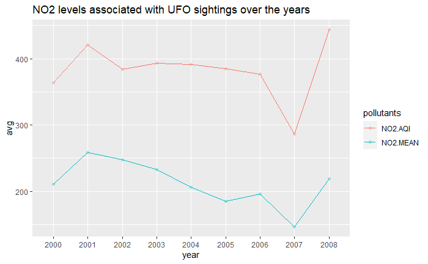

```r
NO2_years <-
    NO2_capital %>%
    group_by(pollutants, year) %>%
    summarise(avg = mean(value)) %>%
    ggplot(aes(x = year, y = avg, color = pollutants)) +
    geom_point(alpha=0.2) + geom_line(aes(group = pollutants)) +
    ggtitle("NO2 levels associated with UFO sightings over the years")

NO2_years
```

*Findings* * NO2.AQI recorded higher pollutant levels associated with UFO sightings, compared to NO2.Mean * The trends of NO2.Mean and NO2.AQI were similar from 2000-2001 and 2006-2008 * The trend of NO2.AQI remained relatively constant from 2002-2005, whereas the trend of NO2.Mean declined during these years

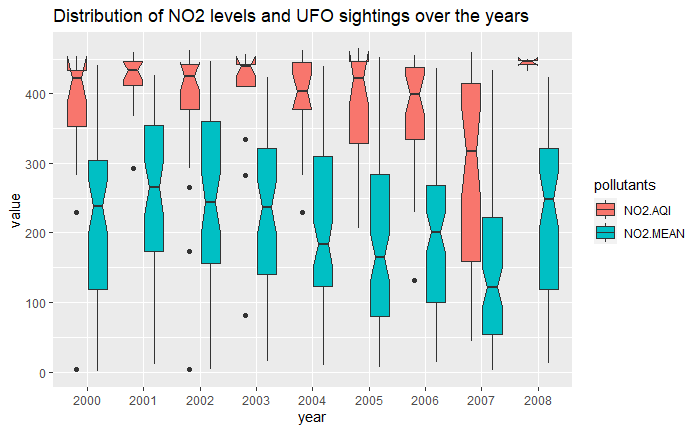

```r
NO2_boxplot <-
  NO2_capital %>%
  ggplot(aes(y = value, x = year)) +
  geom_boxplot(aes(fill = pollutants),
  notch = TRUE) +
  ggtitle("Distribution of NO2 levels and UFO sightings over the years")

NO2_boxplot
```

*Findings* * NO2.Mean has the larger spread, compared to NO2.AQI * Most of the confidence intervals appear wide for both NO2.Mean and NO2, but they are wider for NO2.Mean * There are some outliers, indicated by the outlying points * This plot also shows that NO2.AQI recorded higher pollutant levels associated with UFO sightings, compared to NO2.Mean

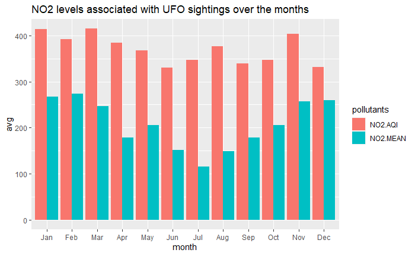

```r
NO2_months <-
  NO2_capital %>%
    group_by(pollutants, month) %>%
    summarise(avg = mean(value)) %>%
    ggplot(aes(x = month, y = avg, fill = pollutants)) +
    geom_bar(stat="identity", position="dodge") +
    ggtitle("NO2 levels associated with UFO sightings over the months")

NO2_months
```

*Findings* * NO2.AQI recorded higher pollutant levels associated with UFO sightings over the months, compared to NO2.Mean * The trend appears somewhat concave up quadratic for both pollutant levels of NO2: both start at high levels, then decrease, before increasing again * January and March showed the highest pollutant levels for NO2.AQI, associated with UFO sightings * June and December showed the lowest pollutant levels for NO2.AQI, associated with UFO sightings * January, February, November, and December showed the highest pollutant levels for NO2.Mean, associated with UFO sightings * July showed the lowest pollutant levels for NO2.Mean, associated with UFO sightings

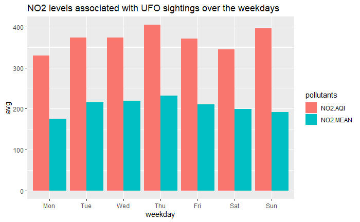

```r
NO2_weekdays <-
  NO2_capital %>%
    group_by(pollutants, weekday) %>%
    summarise(avg = mean(value)) %>%
    ggplot(aes(x = weekday, y = avg, fill = pollutants)) +
    geom_bar(stat="identity", position="dodge") +
    ggtitle("NO2 levels associated with UFO sightings over the weekdays")

NO2_weekdays
```

*Findings* * NO2.AQI recorded higher pollutant levels associated with UFO sightings over the weekdays, compared to NO2.Mean * NO2.AQI and UFO sightings seemed to fluctuate slightly more over the weekdays, compared to NO2.Mean * Thursday showed the highest pollutant levels for NO2.AQI and NO2.Mean, associated with UFO sightings * Monday showed the lowest pollutant levels for NO2.AQI and NO2.Mean, associated with UFO sightings

```r
str(NO2_capital)
```

[output not shown]

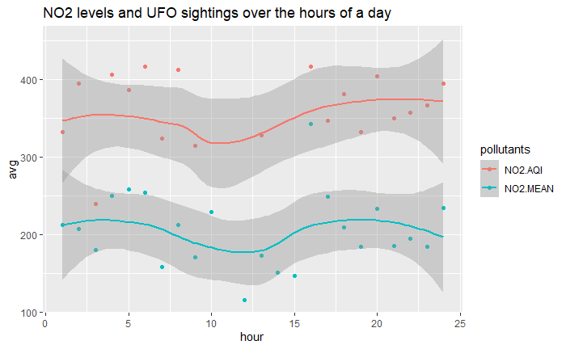

```r
NO2_capital$hour <- as.integer(NO2_capital$hour)

NO2_smooth <-
  NO2_capital %>%
  group_by(pollutants, hour) %>%
  summarise(avg = mean(value)) %>%
  ggplot(aes(x = hour, y = avg, color = pollutants)) +
  geom_point() +
  geom_smooth() +
  ggtitle("NO2 levels and UFO sightings over the hours of a day")

NO2_smooth
```

*Findings* * The trends for both NO2.AQI and NO2.Mean appear curved and thus, somewhat quadratic (instead of linear) * The highest pollutant levels of both NO2.AQI and NO2.Mean appear to be in the early and late hours of a day * The smoothers for both pollutants only very slightly overlap in the very early hours of a day

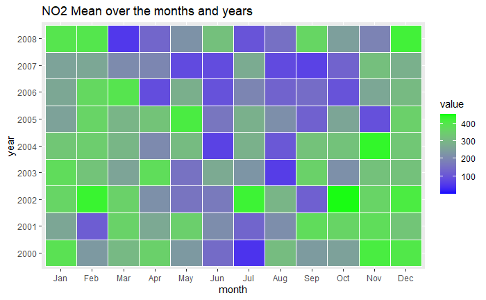

```r
NO2_gradient <-
  NO2_capital %>%
  filter(pollutants!="NO2.AQI") %>%
  ggplot(aes(x = month, y = year, fill = value)) +
  geom_tile(color = "white") + scale_fill_gradient(low ="blue", high ="green") +
  ggtitle("NO2 Mean over the months and years")

NO2_gradient
```

*Findings* * The lowest pollutant values for NO2.Mean, associated with UFO sightings, mainly appear in the early spring, summer, and early fall months (April-October) * The highest pollutant values for NO2.Mean, associated with UFO sightings, mainly appear in the winter months and also border on the early spring months (November-March) * The lowest pollutant values for NO2.Mean, associated with UFO sightings, mainly appear in the years of 2006 and 2007

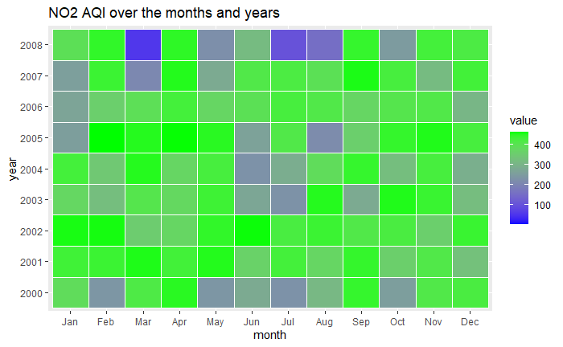

```r
NO2_gradient2 <-
  NO2_capital %>%
  filter(pollutants!="NO2.Mean") %>%
  ggplot(aes(x = month, y = year, fill = value)) +
  geom_tile(colour = "white") + scale_fill_gradient(low ="blue", high ="green") +
  ggtitle("NO2 AQI over the months and years")

NO2_gradient2
```

## For CO

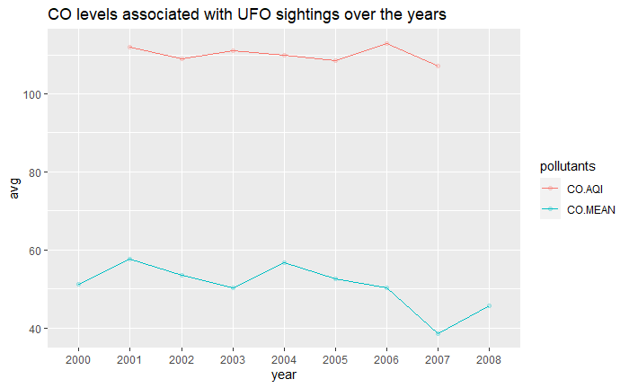

```r
CO_years <-
    CO_capital %>%
    group_by(pollutants, year) %>%
    summarise(avg = mean(value)) %>%
    ggplot(aes(x = year, y = avg, color = pollutants)) +
    geom_point(alpha=0.2) + geom_line(aes(group = pollutants)) +
    ggtitle("CO levels associated with UFO sightings over the years")

CO_years
```

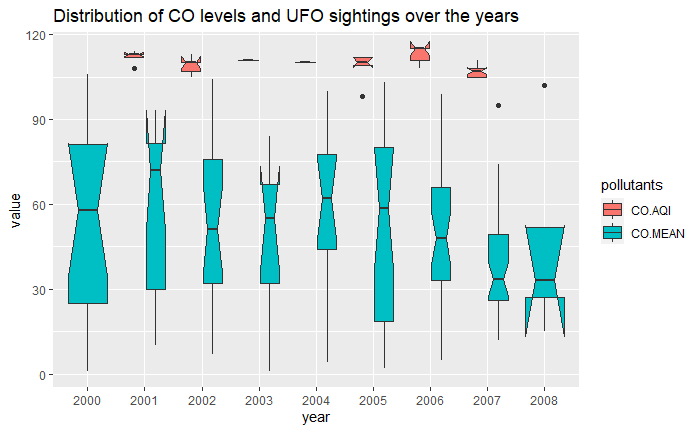

```r
CO_boxplot <-
  CO_capital %>%
  ggplot(aes(y = value, x = year)) +
  geom_boxplot(aes(fill = pollutants),
               notch = TRUE) +
  ggtitle("Distribution of CO levels and UFO sightings over the years")

CO_boxplot
```

*Findings* * CO.Mean has the larger spread, compared to CO.AQI * The confidence intervals appear wide for CO.Mean, but not CO.AQI * There are some outliers, indicated by the outlying points * This plot also shows that CO.AQI recorded higher pollutant levels associated with UFO sightings, compared to CO.Mean

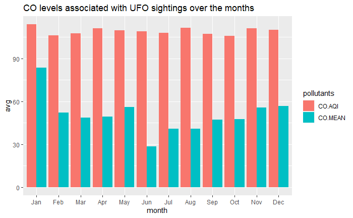

```r
CO_months <-
  CO_capital %>%
    group_by(pollutants, month) %>%
    summarise(avg = mean(value)) %>%
    ggplot(aes(x = month, y = avg, fill = pollutants)) +
    geom_bar(stat="identity", position="dodge") +
    ggtitle("CO levels associated with UFO sightings over the months")

CO_months
```

*Findings* * CO.AQI recorded higher pollutant levels associated with UFO sightings over the months, compared to CO.Mean * The trend for CO.AQI, associated with UFO sightings, remained relatively constant over the months * January showed the highest pollutant levels for CO.Mean, associated with UFO sightings * June showed the lowest pollutant levels for CO.Mean, associated with UFO sightings

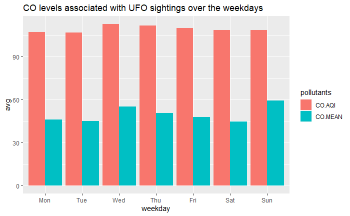

```r
CO_weekdays <-
  CO_capital %>%
    group_by(pollutants, weekday) %>%
    summarise(avg = mean(value)) %>%
    ggplot(aes(x = weekday, y = avg, fill = pollutants)) +
    geom_bar(stat="identity", position="dodge") +
    ggtitle("CO levels associated with UFO sightings over the weekdays")

CO_weekdays
```

*Findings* * CO.AQI recorded higher pollutant levels associated with UFO sightings over the weekdays, compared to CO.Mean * CO.AQI and CO.Mean, both associated with UFO sightings, remained relatively constant over the weekdays * Sunday showed the highest pollutant levels for CO.Mean, associated with UFO sightings

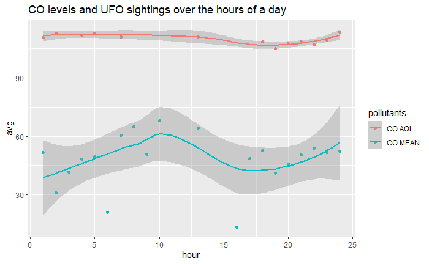

```r
CO_capital$hour <- as.integer(as.factor(CO_capital$hour))

CO_smooth <-
  CO_capital %>%
  group_by(pollutants, hour) %>%
  summarise(avg = mean(value)) %>%
  ggplot(aes(x = hour, y = avg, color = pollutants)) +
  geom_point() +
  geom_smooth() +
  ggtitle("CO levels and UFO sightings over the hours of a day")

CO_smooth
```

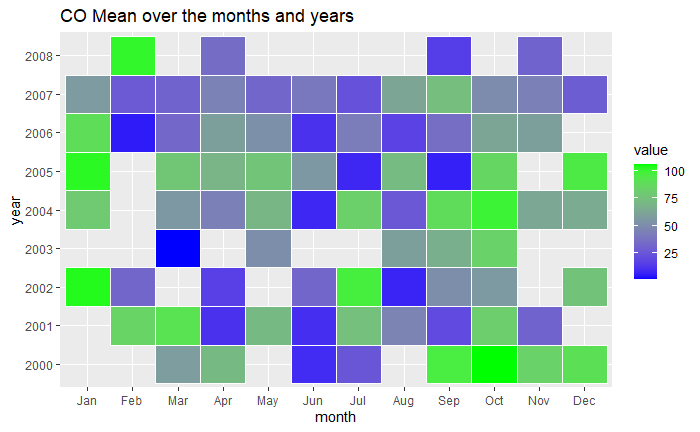

```r
CO_gradient <-
  CO_capital %>%
  filter(pollutants!="CO.AQI") %>%
  ggplot(aes(x = month, y = year, fill = value)) +
  geom_tile(color = "white") + scale_fill_gradient(low ="blue", high ="green") +
  ggtitle("CO Mean over the months and years")

CO_gradient
```

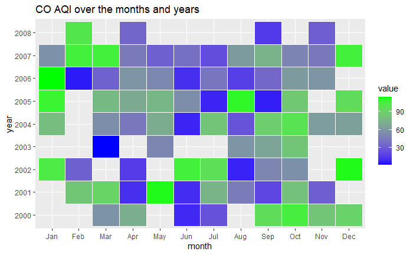

```r
CO_gradient2 <-
  CO_capital %>%
  filter(pollutants!="CO Mean") %>%
  ggplot(aes(x = month, y = year, fill = value)) +
  geom_tile(color = "white") + scale_fill_gradient(low ="blue", high ="green") +
  ggtitle("CO AQI over the months and years")

CO_gradient2
```

## For NO2 & CO

```r
#Combining NO2 & CO data frames
```

```
There were 13 warnings (use warnings() to see them)
```

```r
NO2_CO <-
  rbind(NO2_capital, CO_capital)

kable(head(NO2_CO))
```

| pollutants | date_time | year | month | weekday | hour | value | Region | State | ET |
| --- | --- | --- | --- | --- | --- | --- | --- | --- | --- |
| NO2.MEAN | 2006-09-10 22:00:00 | 2006 | Sep | Mon | 23 | 49 | SOUTH | VA | 1 |
| NO2.MEAN | 2001-10-09 22:00:00 | 2001 | Oct | Wed | 23 | 329 | SOUTH | KY | 1 |
| NO2.MEAN | 2007-07-04 22:00:00 | 2007 | Jul | Thu | 23 | 3 | WEST | CA | 1 |
| NO2.MEAN | 2005-01-11 17:00:00 | 2005 | Jan | Wed | 18 | 7 | WEST | CA | 1 |
| NO2.MEAN | 2000-07-07 21:00:00 | 2000 | Jul | Sat | 22 | 90 | WEST | AZ | 1 |
| NO2.MEAN | 2005-01-08 22:00:00 | 2005 | Jan | Sun | 23 | 8 | WEST | CA | 1 |

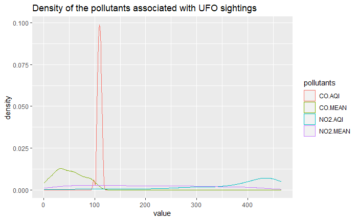

```r
ggplot(NO2_CO, aes(value, color = pollutants)) +
  geom_density() +
  ggtitle("Density of the pollutants associated with UFO sightings")
```

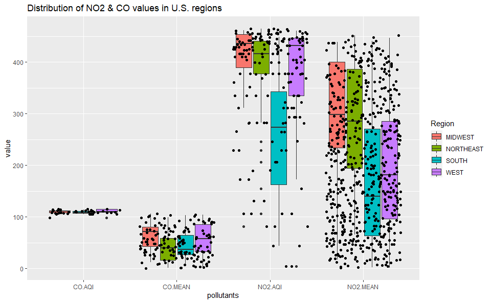

```r
Pollutant_dist <-
  NO2_CO %>%
  ggplot(aes(y = value, x = pollutants)) +
  geom_boxplot(aes(fill = Region)) +
  geom_jitter() +
  ggtitle("Distribution of NO2 & CO values in U.S. regions")

Pollutant_dist
```

*Findings* * Due to the smaller number of cases for CO.AQI, an association with UFO sightings and U.S. region cannot be determined

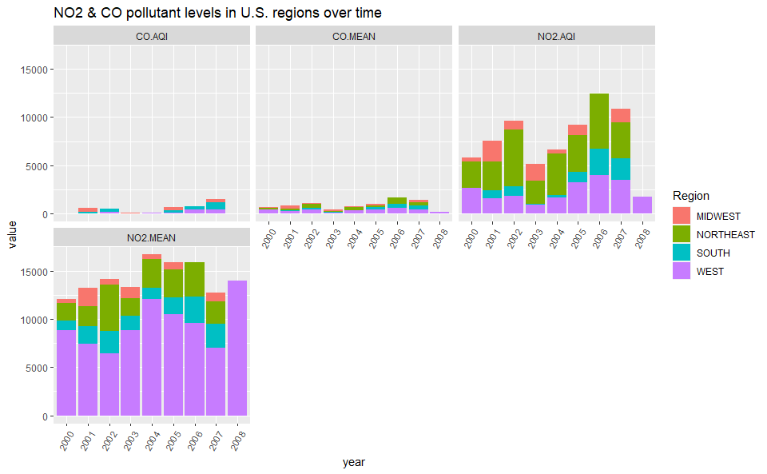

```r
Pollutants_Regions <- ggplot(data=NO2_CO,aes(x=year,y=value ,fill=Region))+geom_bar(stat='identity',position='stack', width=.9)+ facet_wrap(~pollutants,ncol=3) + ggtitle("NO2 & CO pollutant levels in U.S. regions over time") + theme(axis.text.x = element_text(angle = 60, hjust = 1))

Pollutants_Regions
```

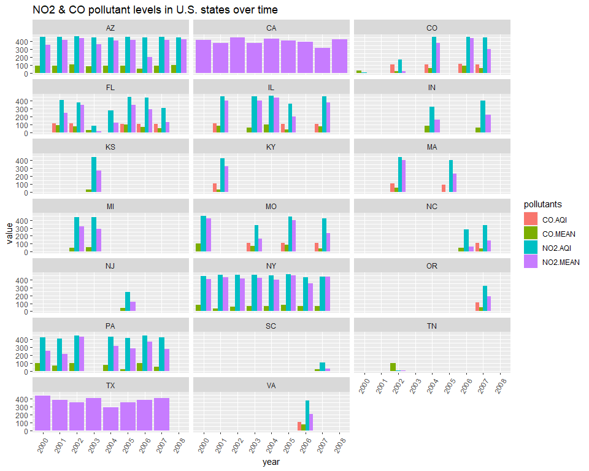

```r
Pollutants_States <- ggplot(data=NO2_CO,aes(x=year,y=value ,fill=pollutants))+geom_bar(stat='identity',position='dodge', width=.9)+ facet_wrap(~State,ncol=3) + theme(axis.text.x = element_text(angle = 60, hjust = 1)) + ggtitle("NO2 & CO pollutant levels in U.S. states over time")

Pollutants_States
```